# gi-ws-06-1

Laura Giese, Johannes Schnell, Alena Schmid

12 Dezember 2017

### Script for deriving VDR-Index (Vertical Distribution Ratio) and a function for deriving height classes

details: see Fusion Manual for details

> script structure:
1. Function for deriving height classes
2. Raw script to calculate VDR index (proceeding gi-ws-05-2)
3. Show results of VDR index

# —————————————————————————

#### 1. First try to write a function to obtain height slices with point density

steps are explained in the script > description: the function “classes(listFiles, mainDir, inDir, heights, cellsize)” wrappes the first part of the fusion workflow the function contains the following steps:

- list input files
- extract groundpoints of las data and create dtm
- normalize las cloud
- create height classes (slices of point cloud from zmin to zmax)
- derive point density per height class (counting points per height class)
- get .asc files with point density of every height class

```r
#---------------------------------------------------------------------------#
############ set environment and read files ###########
#---------------------------------------------------------------------------#

mainDir <- "C:/Users/Laura/Documents/Uni/Rmsc/Data/GIS/POINTCLOUD_processing"
##input folder
inDir <- "/input/"
## output folder
outDir<- "/temp/"
## Fusion binary folder
Fusion<-"C:/FUSION/"

#list las files in input folder
las_files<-list.files(paste0(mainDir,inDir), pattern=".las$", full.names=TRUE,recursive = TRUE)

#write the whole file path and name into a .txt
lapply(las_files, write,paste0(mainDir,inDir,"lidar_files.txt"), append=T)

#vector of height steps (m) for height slizes
zValues<-c(0,2,5,10,15,25,30,50)

#---------------------------------------------------------------------------#
########### function to create height slices with point density #############
#---------------------------------------------------------------------------#

classes<-function(listFiles, mainDir, inDir, heights, cellsize){
  for (j in seq(length(listFiles))){
########### get some basic data########
### basic informations
    system(paste0(Fusion, "catalog.exe ", listFiles[j]," ", mainDir, outDir, j,".html"))
    extend<-read.csv(paste0(mainDir, outDir, j,".csv"), sep = ",", header = T)
### Create a .las with groundpoints only
    system(paste0(paste0(Fusion, "clipdata.exe"," /class:2 ", listFiles[j]," ",
                  mainDir, outDir, "classified_GroundPts_",j,".las "),
                  paste(extend$MinX, extend$MinY, extend$MaxX, extend$MaxY)))

### Create the required PLANS DTM format
    system(paste0(Fusion, "gridsurfacecreate.exe ", mainDir, outDir, "caldern_GridSurf_",j,".dtm ",
                  cellsize," M M 1 32 0 0 ", mainDir, outDir, "classified_GroundPts_",j,".las"))

### normalize heights of las point cloud
    system(paste0(paste0( Fusion, "clipdata.exe", " /height /dtm:",mainDir, outDir,"caldern_GridSurf_",j,".dtm ",
                  listFiles[j], " ",mainDir, outDir, "caldern_normalized_point_cloud_LIDAR",j,".las "),
                  " ", paste(extend$MinX, extend$MinY, extend$MaxX, extend$MaxY)))
    for (i in seq(length(heights)-1)){
### create slice between zmin and zmax
      system(paste0(paste0(Fusion, "clipdata.exe"," /zmin:",heights[i], "/zmax:",heights[i+1], " ", mainDir, outDir, "caldern_normalized_point_cloud_LIDAR",j,".las ",
                    mainDir, outDir, "caldern_normalized_point_cloud_LIDAR_",heights[i],"_",heights[i+1],".las"),
                    " ", paste(extend$MinX, extend$MinY, extend$MaxX, extend$MaxY)))

###create point count for 1m pixel raster in PLANE dtm
      system(paste0(Fusion, "returndensity.exe ",mainDir,outDir, "point_count_all_point_cloud_LIDAR_",heights[i],"_",heights[i+1],"_",cellsize,".dtm ",
                    cellsize, " ", mainDir, outDir, "caldern_normalized_point_cloud_LIDAR_",heights[i],"_",heights[i+1],".las"))

###convert to ascii
      system(paste0(Fusion, "dtm2ascii.exe ",mainDir,outDir, "point_count_all_point_cloud_LIDAR_",heights[i],"_",heights[i+1],"_",cellsize,".dtm ",
                    mainDir,outDir, "point_count_all_point_cloud_LIDAR_",heights[i],"_",heights[i+1],"_",cellsize,".asc"))
    }
  }
}

#---------------------------------------------------------------------------#
########### run function #######
#---------------------------------------------------------------------------#

classes(listFiles=las_files, mainDir=mainDir, inDir= inDir, heights = zValues, cellsize = 1)
```

# —————————————————————————

> description: the script contains the following steps:
- set environment and read files
  - list input files
- preparations for CHM
  - extract groundpoints of las data and create dtm
  - normalize las cloud
- calculate Canopy Height Model
- calculate HOME and save it as .asc file
- merge 4 tiles in study area
- calculate VDR index and save it as .asc file

```r
#---------------------------------------------------------------------------#
############ set environment variables and read files ###########
#---------------------------------------------------------------------------#

#libraries
library("rgdal")
library("raster")

#directories
mainDir <- "C:/Users/Laura/Documents/Uni/Rmsc/Data/GIS/POINTCLOUD_processing"
##input folder
inDir <- "/input/"
## output folder
outDir<- "/temp/vdr/"
## Fusion binary folder
Fusion<-"C:/FUSION/"

#es dürfen nur die las dateien, die später gemerged werden, im input ordner sein
smallLAS = dir(paste0(mainDir, inDir))

#ordner erstellen wird später geloescht
dir.create(paste0(mainDir, outDir))

#ordner wird später gelöscht mit:
del = FALSE

#list all las files in input directory
las_files<-list.files(paste0(mainDir,inDir), pattern=".las$", full.names=TRUE,recursive = TRUE)
##write the whole file path and name into a .txt
lapply(las_files, write, paste0(mainDir,inDir,"lidar_files.txt"), append=T)
#infos über die .las
system(paste0(Fusion, "catalog.exe ", mainDir, inDir, "lidar_files.txt " ,mainDir, outDir, "info_caldern.html"))

#---------------------------------------------------------------------------#
########### preparations for CHM ###########
#---------------------------------------------------------------------------#

### Create a .las with groundpoints only
#.txt --> class_GroundPts.las
system(paste0(Fusion, "clipdata.exe"," /class:2 ", mainDir, inDir, "lidar_files.txt ",
              mainDir, outDir, "classified_GroundPts.las ", "476000 5630000 479000 5633000"))

### Create the required PLANS DTM format
#class_GroundPts.las --> caldernGridSurf.dtm
system(paste0(Fusion, "gridsurfacecreate.exe ", mainDir, outDir, "caldern_GridSurf.dtm ",
              "1 M M 1 32 0 0 ", mainDir, outDir, "classified_GroundPts.las"))

### normalize heights of las point cloud
#CaldernGridSurf.dtm --> cald_NORMALIZED_poit_cloud.las
system(paste0(Fusion, "clipdata.exe", " /height /dtm:", mainDir, outDir,"caldern_GridSurf.dtm ",
              mainDir, inDir, "lidar_files.txt ", mainDir, outDir, "caldern_normalized_point_cloud_LIDAR.las ",
              "476000 5630000 479000 5633000"))

#---------------------------------------------------------------------------#
########### calculate CHM ###########
#---------------------------------------------------------------------------#

##canopymodel canopy_surface.dtm
#normalized_point_cloud --> canopy surface, diese ist CH in der endformel
system(paste0(Fusion, "canopymodel.exe"," /ascii ", mainDir, outDir, "canopy_surfaceX.ascii ", "1 M M 1 32 0 0 ",
              mainDir, outDir, "caldern_normalized_point_cloud_LIDAR.las "))

#dtm2tif_canopymodel, wandelt .dtm in .tif um
##vllt werden hier werte gestreckt? -> besser nicht verwenden

#system(paste0(Fusion, "DTM2TIF.exe ", mainDir, outDir, "canopy_surfaceX.dtm "))

#---------------------------------------------------------------------------#
########### calculate HOME ###########
#---------------------------------------------------------------------------#

#calculate 50th percentile of Lidar point cloud per 1mm pixel
#output: .csv files are important!
for(i in 1:4){
  system(paste0(Fusion, "gridmetrics.exe ","/raster:p50 ", mainDir, outDir,
                "caldern_GridSurf.dtm ", "0 ", "1 ", mainDir, outDir,paste0("HOMEsmall",i,".dtm ") , mainDir, inDir, smallLAS[i] ))
}

#take 31 column of all_returns_elevation_stats.csv as this is the 50th percentile
for(i in 1:4){
  system(paste0(Fusion, "CSV2Grid.exe ", mainDir, outDir, paste0("HOMEsmall",i,"_all_returns_elevation_stats.csv "), "31 ",
                mainDir, outDir, paste0("HOMEsmallbeforeMERGE",i,".asc ")))
}

#---------------------------------------------------------------------------#
########### merge 4 tiles in study area ###########
#---------------------------------------------------------------------------#

#generate one .txt file for merging 4 tiles
smallASCs = c()
for(i in 1:4){
  a = paste0(mainDir, outDir, "HOMEsmallbeforeMERGE",i,".asc ")
  a -> smallASCs[i]
}
write(x = smallASCs, file = "temp/vdr/txtformerge.txt")

#merge smalltifraster files
system(paste0(Fusion, "MergeRaster.exe ","/overlap:average ", mainDir, outDir, "HOMEp50.asc ",mainDir, outDir, "txtformerge.txt" ))

#---------------------------------------------------------------------------#
########### calculate VDR index and save it as .asc file ###########
#---------------------------------------------------------------------------#

#calculation of VDR index
ch = raster(paste0(mainDir, outDir, "canopy_surfaceX.asc"))
HOME = raster(paste0(mainDir, outDir, "HOMEp50.asc"))
origin(HOME)[] <- origin(ch)
VDR = (ch-HOME)/ch
#delete negative values
VDR@data@values[which(VDR@data@values >= 1)] <- NA
VDR@data@values[which(VDR@data@values < 0)] <- NA

#save output
writeRaster(VDR, "VDR.asc")

#delete textfile with listed lidar files of input folder
file.remove("C:/Users/Laura/Documents/Uni/Rmsc/Data/GIS/POINTCLOUD_processing/input/lidar_files.txt")

# if you run the whole skript again, delete the output directory, that you can create a new one in the next run
if(del == T){
  file.remove(paste0(mainDir, outDir,dir(paste0(mainDir, outDir))))
}
```

# —————————————————————————

#### 3. Show result of VDR index

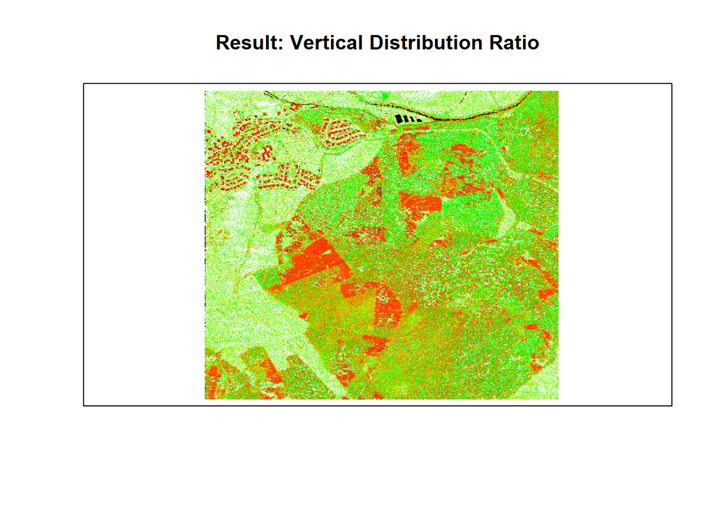